# Ejercicios 1 a 3 hogg fitting

## Preparación previa

Primero vamos a preparar los datos para usarlos facilmente

```r
library(MASS)
x <- c(201, 244, 47, 287, 203, 58, 210, 202, 198, 158,165,201,157,131,166,160,186,125,218,146)
y <- c(592,401,583,402,495,173,479,504,510,416,393,442,317,311,400,337,423,334,533,344)
stdy <- c(61,25,38,15,21,15,27,14,30,16,14,25,52,16,34,31,42,26,16,22)
stdx <- c(9,4,11,7,5,9,4,4,11,7,5,5,5,6,6,5,9,8,6,5)
roxy <- c(-0.84, 0.31,0.64,-0.27,-0.33,0.67,-0.02,-0.05,-0.84,-0.69,0.3,-0.46,-0.03,0.5,0.73,-0.52,0.9,0.4,-0.78,-0.56)

df <- data.frame(x,y,stdy,stdx,roxy)
df["varx"] <- stdx^2
df["vary"] <- stdy^2
df["rosd"] <- roxy*stdx*stdy
df["uncertxn"] <- x-stdx
df["uncertxp"] <- x+stdx
df["uncertyn"] <- y-stdy
df["uncertyp"] <- y+stdy
mstd1 <- diag(df[,"vary"])
mstd2 <- diag(df[5:20,"vary"])
```

## Ejercicio 1

En este ejercicio lo que se nos pide es que usemos regresion lineal simple para hacer algo similar a la figura 1 usando un modelo lineal tal que

$y=mx+b$

Para hallar los parámetros $W_{ML}$ vamos a hacer lo siguiente

$\left[\begin{array}{c} b\\ m \end{array}\right] = \left [ A^T C^{-1} A \right ]^{-1} A^T C^{-1} Y$

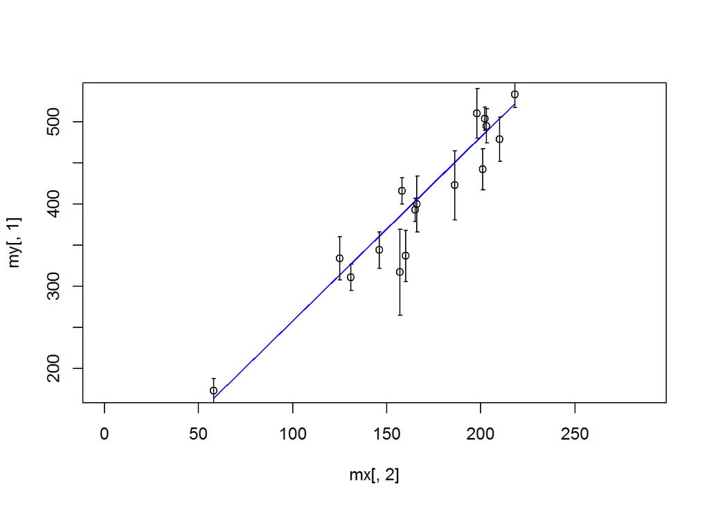

```r
mx <- cbind(rep(1,16),df[5:20,"x"]) # matriz de diseño
my <- matrix(df[5:20,"y"], ncol=1,nrow=16) # variable objetivo
model <- solve(t(mx) %*% solve(mstd2) %*% mx) %*% t(mx) %*% solve(mstd2) %*% my
predicty1 <- mx %*% model
plot(mx[,2], my[,1], xlim = c(0,max(x)))
lines(mx[,2], predicty1, col="blue")
segments(mx[,2], df[5:20,"uncertyn"], mx[,2], df[5:20, "uncertyp"])
segments(mx[,2]-1, df[5:20,"uncertyn"], mx[,2]+1, df[5:20, "uncertyn"])
segments(mx[,2]-1, df[5:20,"uncertyp"], mx[,2]+1, df[5:20, "uncertyp"])
```

Vemos que se ajusta correctamente a la figura 1. Los parámetros son

```r
model
```

```
##           [,1]
## [1,] 34.047728
## [2,]  2.239921
```

Y la varianza o incertidumbre en m sería

```r
solve(t(mx) %*% solve(mstd2) %*% mx)
```

```
##            [,1]        [,2]
## [1,] 332.922601 -1.88954491
## [2,]  -1.889545  0.01161663
```

## Ejercicio 2

En este ejercicio se trata de reproducir el ejercicio 1 pero tomando todos los puntos.

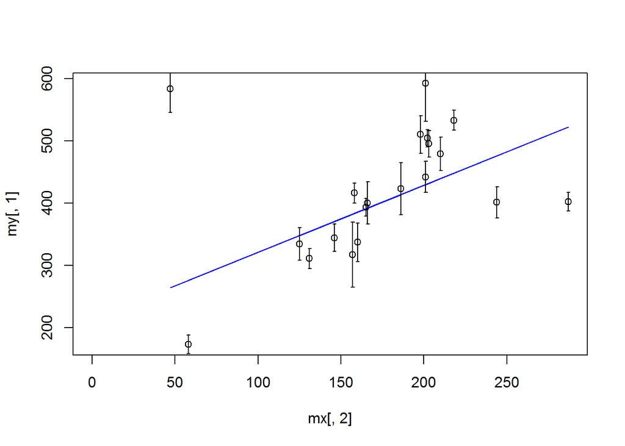

```r
mx <- cbind(x^0, x) # matriz de diseño
my <- matrix(df[1:20,"y"], ncol=1,nrow=20) # variable objetivo
model <- model <- solve(t(mx) %*% solve(mstd1) %*% mx) %*% t(mx) %*% solve(mstd1) %*% my
predicty1 <- mx %*% model
plot(mx[,2], my[,1], xlim = c(0,max(x)))
lines(mx[,2], predicty1, col="blue")
segments(mx[,2], df[1:20,"uncertyn"], mx[,2], df[1:20, "uncertyp"])
segments(mx[,2]-1, df[1:20,"uncertyn"], mx[,2]+1, df[1:20, "uncertyn"])
segments(mx[,2]-1, df[1:20,"uncertyp"], mx[,2]+1, df[1:20, "uncertyp"])
```

Se ve que en este caso, al incluir los nuevos puntos el ajuste es mucho peor.

```r
model
```

```
##         [,1]
##   213.273492
## x   1.076748
```

Y la varianza o incertidumbre en m sería

```r
solve(t(mx) %*% solve(mstd1) %*% mx)
```

```
##                        x
##   207.188189 -1.05427206
## x  -1.054272  0.00599181
```

## Ejercicio 3

En este caso se trata de usar una forma cuadratica de la expresión ignorando los primeros puntos al igual que en el ejercicio 1.

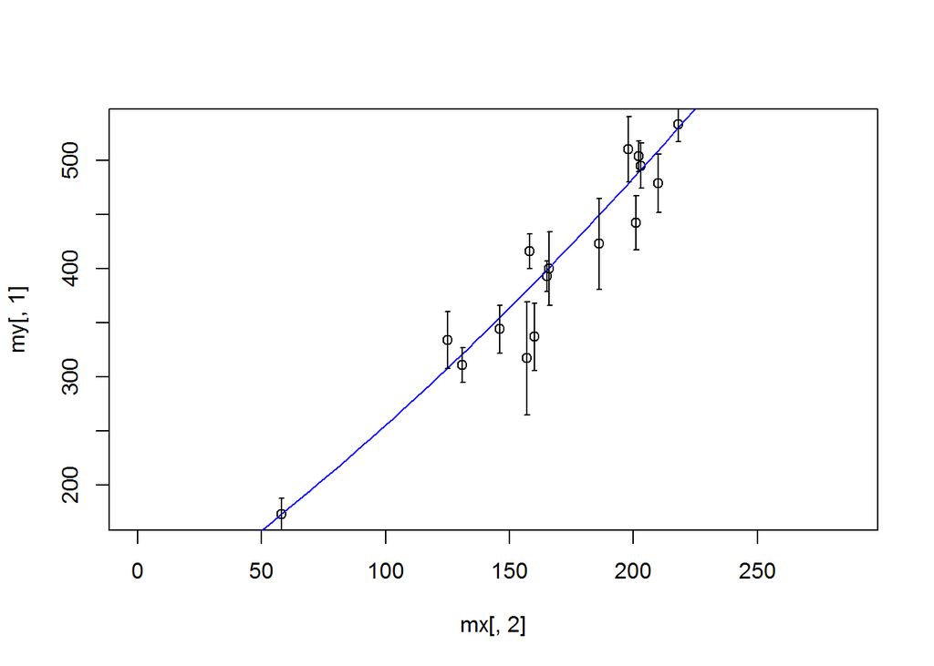

```r
nx <- seq(from=0,to=300, length.out=100)
mx <- cbind(rep(1,16),df[5:20,"x"], df[5:20,"x"]^2) # matriz de diseño
nmx <- cbind(nx^0, nx, nx^2) # nueva, sobre la que se usará el modelo
my <- matrix(df[5:20,"y"], ncol=1,nrow=16) # variable objetivo
model <- solve(t(mx) %*% solve(mstd2) %*% mx) %*% (t(mx) %*% solve(mstd2) %*%  my)
predicty1 <- nmx %*% model
plot(mx[,2], my[,1], xlim = c(0,max(x)))
lines(nx, predicty1, col="blue")
segments(mx[,2], df[5:20,"uncertyn"], mx[,2], df[5:20, "uncertyp"])
segments(mx[,2]-1, df[5:20,"uncertyn"], mx[,2]+1, df[5:20, "uncertyn"])
segments(mx[,2]-1, df[5:20,"uncertyp"], mx[,2]+1, df[5:20, "uncertyp"])
```

Y los parámetros $W_{ML}$

```r
model
```

```
##              [,1]
## [1,] 72.894626472
## [2,]  1.596050452
## [3,]  0.002298888
```

## Ejercicio 4

Tomamos la expresión de partida para la log-verosimilitud de los datos dado el parámetro del modelo $\dfrac{1}{2T}\sum^{N}\left(y_{i}-\mu\right)^{2}$

derivando e igualando a 0

$0=\dfrac{1}{T}\left(\sum y_{i}-\sum\mu\right)$

$\dfrac{1}{T}\sum y_{i}=\dfrac{1}{T}N\mu$ $\dfrac{1}{N}\sum y_{i}=\mu_{ML}$

## Ejercicio 5

Tomar $(Y-AX)^T(Y-AX)$ (7 en Hogg fitting) y demostrar, derivando, que $X=\left [ A^TC^{-1}A \right ]^{-1}\left [ A^TC^{-1}Y \right ]$

### Solución

Este ejercicio es igual al 3.3 de PRML de Bishop. $\dfrac{1}{2} \sum^Nr_i\left ( t_i-w^T\phi(x_i) \right )^2$

derivando para obtener el gradiente, tal como en 3.13 de Bishop

$\sum r_i\left ( t_i-w^T\phi(x_i) \right )\phi(x_i)^T$

igualando a 0 y reordenando

$0=\sum r_i t_i \phi(x_i)^T -w^T \left ( \sum r_i \phi(x_i) \phi(x_i)^T \right )$

que podemos expresarlo (resolviendo para w), si definimos $r_i=$ cada elemento de la diagonal de $C^{-1}$ como

$\left ( \Phi^TC^{-1} \Phi \right )^{-1} \left (\Phi C^{-1}t \right )$

Para demostrarlo basta con reordenar

$\sum r_i t_i \phi(x_i)^T -w^T \left ( \sum r_i \phi(x_i) \phi(x_i)^T \right )$ $= \underbrace{\sum_i r_i t_i\phi(x_i)^T}_{\Phi^T C^{-1} t} \underbrace{\left ( \sum_i r_i \phi(x_i)\phi(x_i)^T \right )^{-1} }_{(\Phi^T C^{-1} \Phi)^{-1}}=w^T$

haciendo la traspuesta ya tenemos el resultado final.